# Exploración de datos

*Una imagen vale más que mil palabras*

No solo se trata de tener una imagen de los datos sino una buena imagen y cada imagen tiene un caso de uso más apropiado. Entonces tenemos un area especifica para poder elaborar gráficos de calidad, así también debemos contar con una página para tener los tipos de gráficas y su uso, ademas de su implementación en algún lenguaje o herramienta de programación.

Catalogo: https://datavizproject.com/

## Explorando la página.

En la pagina nos encontramos con gráficas de diferente utilidad, podemos hacer una indexacion por Familia, Input (Tipos de datos de entrada), por forma que tiene la gráfica (Shape).

- Donut chart o variación de gráfica de pastel
- Diagrama radial.
- Diagrama de dispersión

Hasta el momento solo nos hemos enfocado en analizar una sola columna. A este proceso se le llama **análisis univariado**, es decir me estoy enfocando en una sola variable y en ella estoy analizando algunos estadísticos que vimos. Ver como se comportan las variables numéricas, segmentandolas con variables categóricas.

¿Qué pasa cuando quiero analizar la relación de una variable con respecto de otra? En el caso de que ambas variables sean numéricas, lo que hacemos es trabajar con un concepto muy importante en estadística **"correlación"**. La correlación es una medida de la relación entre dos variables. Es un concepto que hay manejar muy apropiadamente porque puede generar confusion.

# Extras

[figure not shown]

⚠️Recordemos que una correlación no significa una relación de causalidad. Por ejemplo, en el siguiente gráfico, vemos cómo la tasa de divorcio en Maine se correlaciona con el consumo per cápita de margarina.

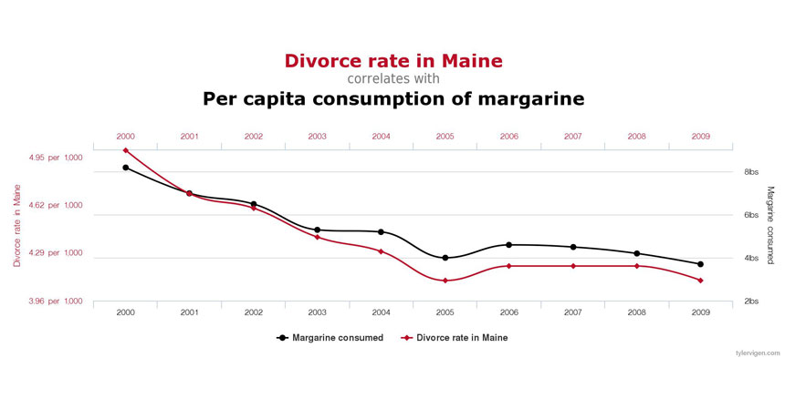

Hay correlación, pero no ninguna es causa de la otra.

### Páginas web

- [From Data to Viz](https://www.data-to-viz.com/)
- [Data Viz Project](https://datavizproject.com/) A mí me encanta la página que recomienda. Si colocas el tipo de gráfico seguido de tu librería favorita es muy probable que encuentres la documentación. Así aprendí a utilizar el Violin Plot.
- Si quieren realmente tener buenas bases de Visualización de datos les recomiendo este Libro: The truthful art, de Alberto Cairo.